# Analyzing Individual BGG Users

Phil Henrickson

2022-01-02

# **tomtermite’s** BoardGameGeek Collection

This notebook contains a set of analyses for the selected user’s boardgamegeek collection. The bulk of the analysis is focused on building a user-specific predictive model to predict the games that tomtermite is likely to own. This enables to ask questions like, based on the games the user currently owns, what games are a good fit for their collection? What upcoming games are they likely to purchase?

This analysis is based on data from BoardGameGeek that was last updated on **2021-12-20.**

# 1 Collection Overview

We can look at a basic description of the number of games that the user owns, has rated, has previously owned, etc.

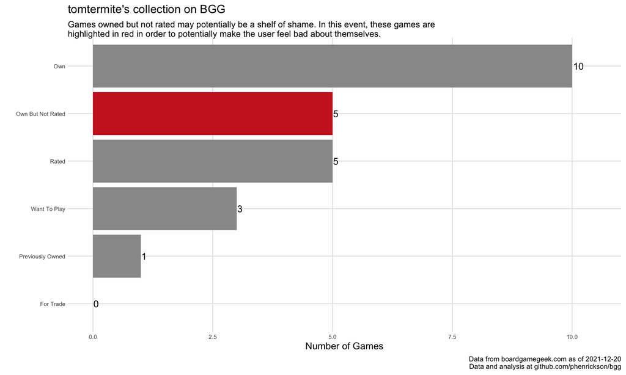

What years has the user owned/rated games from? While we can’t see when a user added or removed a game from their collection, we can look at their collection by the years in which their games were published.

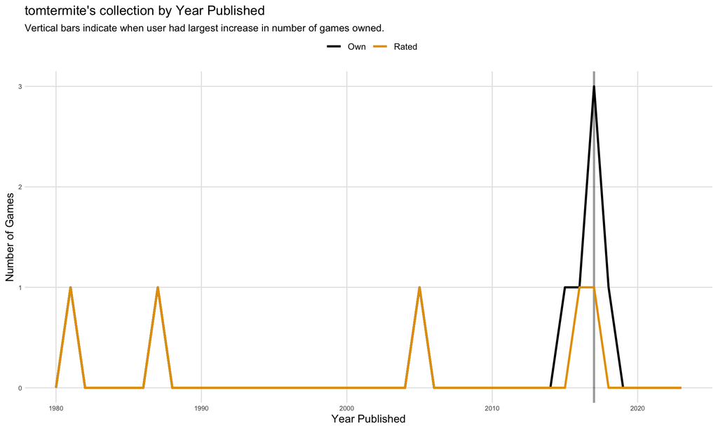

## 1.1 What types of games does tomtermite own?

We can look at the most frequent types of categories, mechanics, designers, and artists that appear in a user’s collection.

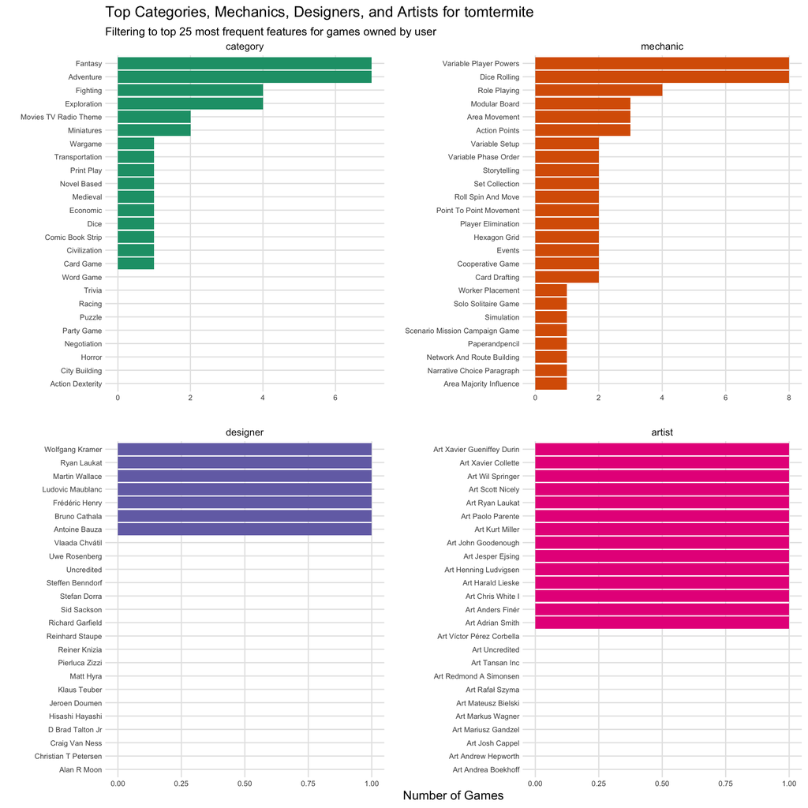

# 2 Modeling **tomtermite’s** Collection

| username | dataset | period | games_owned | games_rated | games_played |
| --- | --- | --- | --- | --- | --- |
| tomtermite | training | published before 2018 | 9 | 5 | 9 |
| tomtermite | test | published 2018 or later | 1 | 0 | 1 |

There are two main (binary) outcomes we will be modeling for the user.

The first, **own** refers to whether the user currently lists a game as owned in their collection. The second, **played** refers to whether the user currently owns, has rated, or previously owned a game. This means the latter will generally have a larger list of games, but may still be a useful category to examine for people who play lots of games without necessarily owning them.

We will train predictive models to learn the probability that the user will own or play individual games based on their features.

## 2.1 Coefficients for tomtermite

We can examine coefficients from the trained modes, which are penalized logistic regressions fit to our two main outcomes. Positive values indicate that a feature increases a user’s probabilility of owning/rating a game, while negative values indicate a feature decreases the probability.

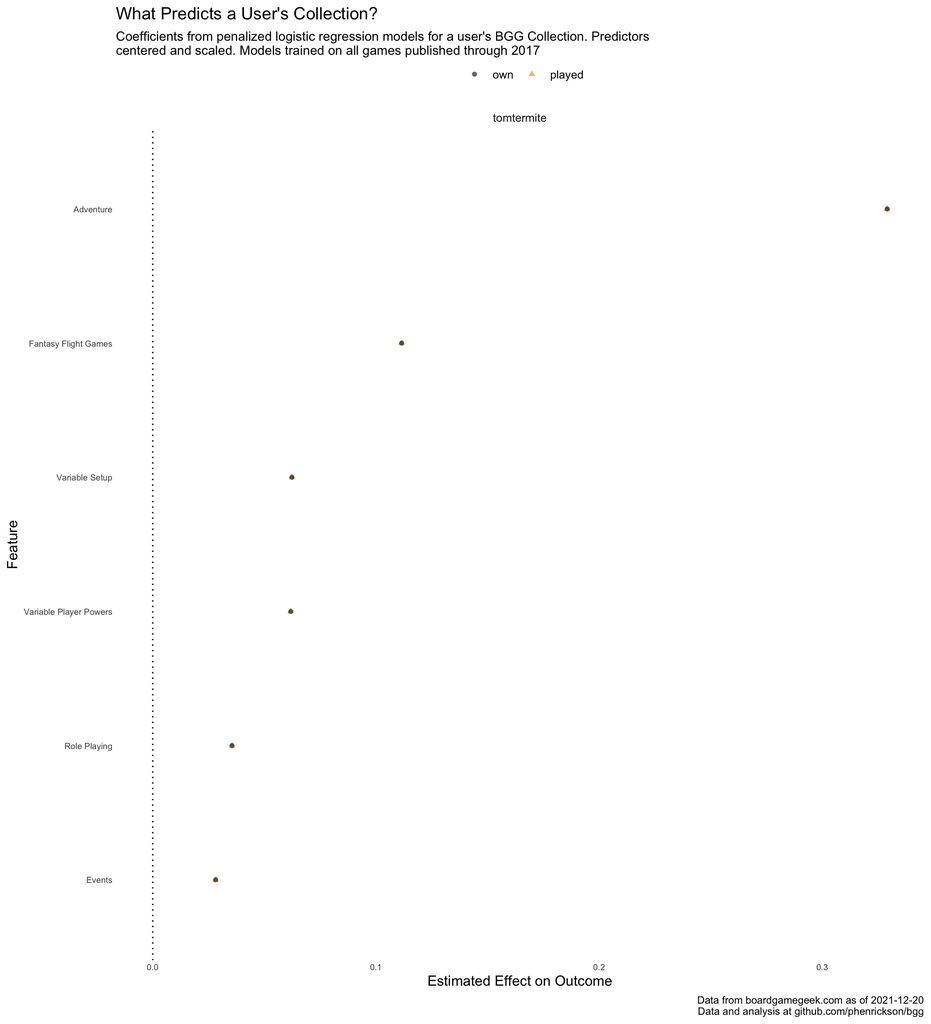

## 2.2 Visualizing Predictors for tomtermite’s Collection

Why did the model identify these features? We can make density plots of the important features for predicting whether the user owned a game. Blue indicates the density for games owned by the user, while grey indicates the density for games not owned by the user.

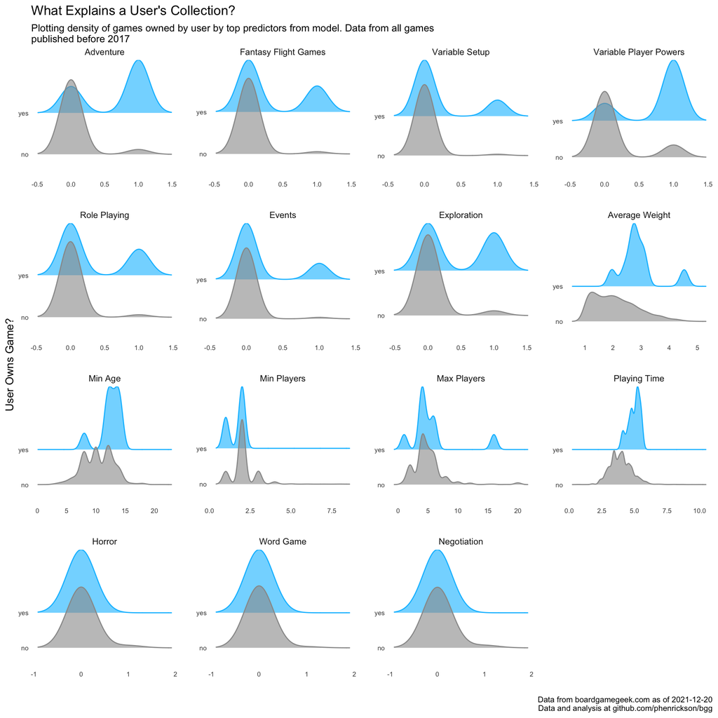

Binary predictors can be difficult to see with this visualization, so we can also directly examine the percentage of games in a user’s collection with a predictor vs the percentage of all games with that predictor.

| username | Feature | % of Games with Feature In_Collection | % of Games with Feature All_Games | Ratio |
| --- | --- | --- | --- | --- |
| tomtermite | Variable Setup | 22.2% | 1.8% | 12.6 |
| tomtermite | Fantasy Flight Games | 33.3% | 2.9% | 11.6 |
| tomtermite | Events | 22.2% | 1.9% | 11.5 |
| tomtermite | Adventure | 66.7% | 6.1% | 11.0 |
| tomtermite | Role Playing | 33.3% | 3.1% | 10.6 |
| tomtermite | Exploration | 44.4% | 5.5% | 8.1 |
| tomtermite | Variable Player Powers | 77.8% | 15.7% | 5.0 |
| tomtermite | Medieval | 11.1% | 6.2% | 1.8 |
| tomtermite | Horror | 0.0% | 3.7% | 0.0 |
| tomtermite | Word Game | 0.0% | 1.8% | 0.0 |
| tomtermite | Negotiation | 0.0% | 4.0% | 0.0 |
| tomtermite | Trivia | 0.0% | 2.0% | 0.0 |
| tomtermite | Puzzle | 0.0% | 2.8% | 0.0 |
| tomtermite | City Building | 0.0% | 4.1% | 0.0 |
| tomtermite | Party Game | 0.0% | 8.8% | 0.0 |
| tomtermite | Racing | 0.0% | 3.1% | 0.0 |
| tomtermite | Action Dexterity | 0.0% | 5.1% | 0.0 |
| tomtermite | Mafia | 0.0% | 0.7% | 0.0 |
| tomtermite | Trains | 0.0% | 2.3% | 0.0 |
| tomtermite | Prehistoric | 0.0% | 1.0% | 0.0 |
| tomtermite | Realtime | 0.0% | 4.0% | 0.0 |
| tomtermite | Sports | 0.0% | 2.2% | 0.0 |
| tomtermite | Deduction Game | 0.0% | 6.1% | 0.0 |
| tomtermite | Murdermystery | 0.0% | 1.6% | 0.0 |
| tomtermite | Childrens Game | 0.0% | 6.3% | 0.0 |

# 3 Assess Model’s Performance on Training Set

Before predicting games in upcoming years, we can examine how well the model did and what games it liked in the training set. In this case, we used resampling techniques (cross validation) to ensure that the model had not seen a game before making its predictions.

## 3.1 Separation Plot

An easy way to examine the performance of classification model is to view a separation plot. We plot the predicted probabilities from the model for every game (from resampling) from lowest to highest. We then overlay a blue line for any game that the user does own. A good classifier is one that is able to *separate* the blue (games owned by the user) from the white (games not owned by the user), with most of the blue occurring at the highest probabilities (right side of the chart).

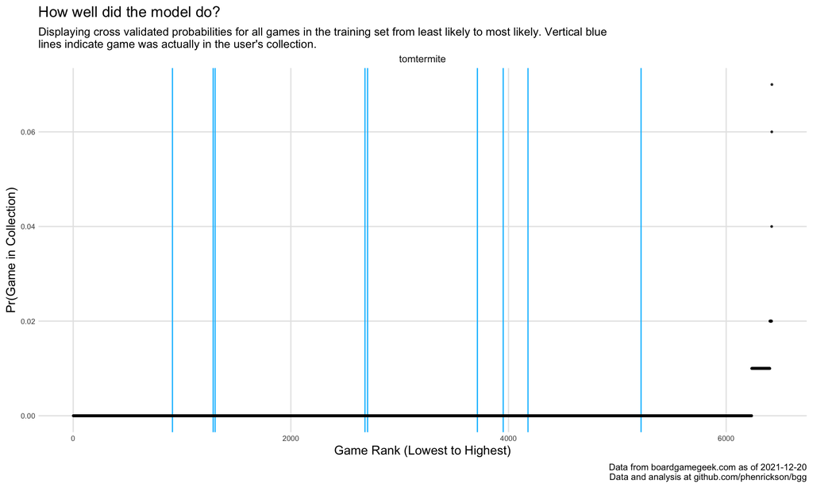

## 3.2 Top Games for **tomtermite** from Training Set

We can display this information in table form, displaying the 100 games with the highest probability of ownership, adding a blue line when the user does own the game.

| username | yearpublished | game_id | name | pred_played | pred_own | actual_played | actual_own |
| --- | --- | --- | --- | --- | --- | --- | --- |
| tomtermite | 2005 | 15987 | Arkham Horror | 0.07 | 0.07 | 0 | 0 |
| tomtermite | 1980 | 3248 | Citadel of Blood | 0.06 | 0.06 | 0 | 0 |
| tomtermite | 1972 | 1511 | Outdoor Survival | 0.04 | 0.04 | 0 | 0 |
| tomtermite | 2002 | 3201 | Lord of the Rings: The Confrontation | 0.02 | 0.02 | 0 | 0 |
| tomtermite | 1980 | 4746 | Dungeons & Dragons Computer Labyrinth Game | 0.02 | 0.02 | 0 | 0 |
| tomtermite | 2010 | 71061 | DungeonQuest (Third Edition) | 0.02 | 0.02 | 0 | 0 |
| tomtermite | 2010 | 25292 | Merchants & Marauders | 0.02 | 0.02 | 0 | 0 |
| tomtermite | 2013 | 128442 | Relic | 0.02 | 0.02 | 0 | 0 |
| tomtermite | 2017 | 232918 | Fallout | 0.02 | 0.02 | 0 | 0 |
| tomtermite | 2014 | 157958 | DungeonQuest Revised Edition | 0.02 | 0.02 | 0 | 0 |
| tomtermite | 2013 | 146021 | Eldritch Horror | 0.02 | 0.02 | 0 | 0 |
| tomtermite | 1975 | 1339 | Dungeon! | 0.02 | 0.02 | 0 | 0 |
| tomtermite | 2006 | 23107 | Drakon (Third Edition) | 0.02 | 0.02 | 0 | 0 |
| tomtermite | 2017 | 188920 | This War of Mine: The Board Game | 0.02 | 0.02 | 0 | 0 |
| tomtermite | 2000 | 823 | The Lord of the Rings | 0.02 | 0.02 | 0 | 0 |
| tomtermite | 2011 | 83330 | Mansions of Madness | 0.02 | 0.02 | 0 | 0 |
| tomtermite | 2016 | 205059 | Mansions of Madness: Second Edition | 0.02 | 0.02 | 0 | 0 |
| tomtermite | 2006 | 24935 | Anima: Shadow of Omega | 0.02 | 0.02 | 0 | 0 |
| tomtermite | 2014 | 164153 | Star Wars: Imperial Assault | 0.02 | 0.02 | 0 | 0 |
| tomtermite | 2004 | 13751 | Under the Shadow of the Dragon | 0.01 | 0.01 | 0 | 0 |
| tomtermite | 1977 | 3661 | Imperium: Empires in Conflict – Worlds in the Balance | 0.01 | 0.01 | 0 | 0 |
| tomtermite | 2008 | 23418 | Pursuit of Glory | 0.01 | 0.01 | 0 | 0 |
| tomtermite | 2009 | 42124 | Dungeon Twister 2: Prison | 0.01 | 0.01 | 0 | 0 |
| tomtermite | 2016 | 199242 | Mini Rogue: A 9-Card Print-and-Play Game | 0.01 | 0.01 | 0 | 0 |
| tomtermite | 1990 | 8630 | Advanced Space Crusade | 0.01 | 0.01 | 0 | 0 |
| tomtermite | 2004 | 11159 | Dungeoneer: Haunted Woods of Malthorin | 0.01 | 0.01 | 0 | 0 |
| tomtermite | 2009 | 36932 | Claustrophobia | 0.01 | 0.01 | 0 | 0 |
| tomtermite | 2001 | 1426 | Lord of the Rings: The Search | 0.01 | 0.01 | 0 | 0 |
| tomtermite | 1978 | 3463 | Wizard | 0.01 | 0.01 | 0 | 0 |
| tomtermite | 2004 | 11161 | Dungeoneer: Den of the Wererats | 0.01 | 0.01 | 0 | 0 |

[output cut: 70 more lines]

We can also more formally assess how well the model did in resampling by looking at the area under the receiver operating characteristic. A perfect model would receive a score of 1, while a model that cannot predict the outcome will default to a score of 0.5. The extent to which something is a *good* score depends on the setting, but generally anything in the .8 to .9 range is very good while the .7 to .8 range is perfectly acceptable.

| username | outcome_type | .metric | .estimator | .estimate |
| --- | --- | --- | --- | --- |
| tomtermite | own | roc_auc | binary | 0.683 |
| tomtermite | played | roc_auc | binary | 0.683 |

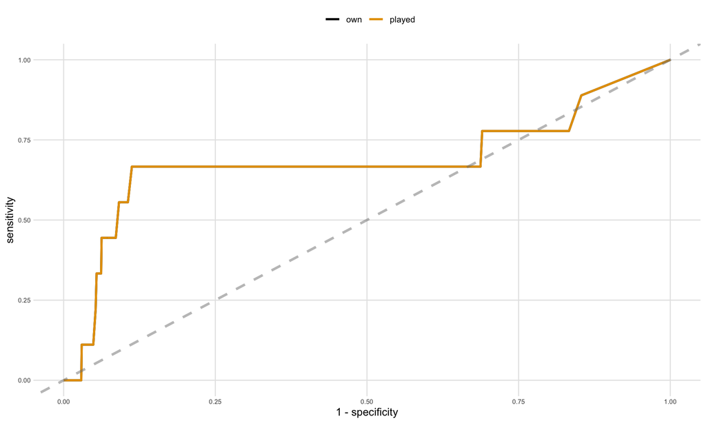

Another way to think about the model performance is to view its lift, or its ability to detect the positive outcomes over that of a null model. High lift indicates the model can much more quickly find all of the positive outcomes (in this case, games owned or played by the user), while a model with no lift is no better than random guessing.

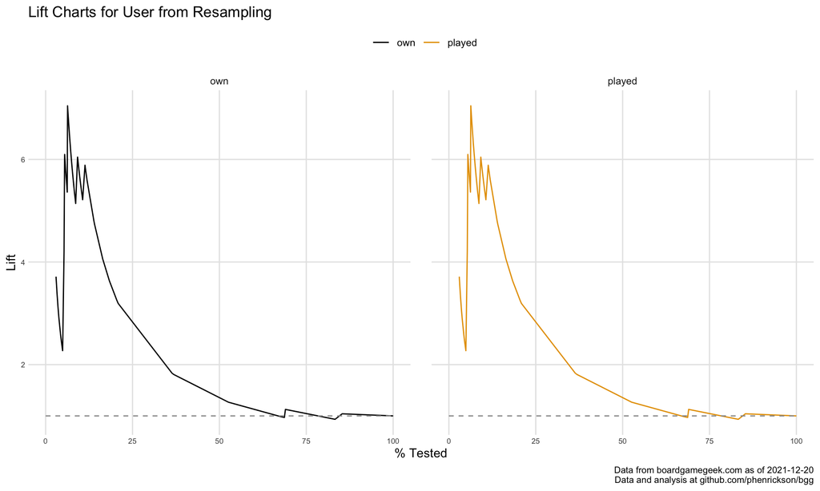

## 3.3 Most and Least Likely Games

What games does the model think tomtermite is **most likely to own** that are **not** in their collection?

| username | yearpublished | game_id | name | pred_own | actual_own |
| --- | --- | --- | --- | --- | --- |
| tomtermite | 2005 | 15987 | Arkham Horror | 0.07 | 0 |
| tomtermite | 1980 | 3248 | Citadel of Blood | 0.06 | 0 |
| tomtermite | 1972 | 1511 | Outdoor Survival | 0.04 | 0 |
| tomtermite | 2002 | 3201 | Lord of the Rings: The Confrontation | 0.02 | 0 |
| tomtermite | 1980 | 4746 | Dungeons & Dragons Computer Labyrinth Game | 0.02 | 0 |

What games does the model think tomtermite is **least likely to own** that **are** in their collection?

| username | yearpublished | game_id | name | pred_own | actual_own |
| --- | --- | --- | --- | --- | --- |
| tomtermite | 1981 | 1631 | Barbarian Prince | 0 | 1 |
| tomtermite | 2017 | 98527 | Gloom of Kilforth: A Fantasy Quest Game | 0 | 1 |
| tomtermite | 2015 | 181530 | Runebound (Third Edition) | 0 | 1 |
| tomtermite | 2017 | 195421 | Near and Far | 0 | 1 |
| tomtermite | 2017 | 233247 | Civilization: A New Dawn | 0 | 1 |

## 3.4 Top Games by Year

Top 25 games most likely to be owned by the user in each year, highlighting in blue the games that the user has owned/played.

| rank | 2009 | 2010 | 2011 | 2012 | 2013 | 2014 | 2015 | 2016 | 2017 |
| --- | --- | --- | --- | --- | --- | --- | --- | --- | --- |
| 1 | Dungeon Twister 2: Prison | DungeonQuest (Third Edition) | Mansions of Madness | Agents of SMERSH | Relic | DungeonQuest Revised Edition | Chaosmos | Mansions of Madness: Second Edition | Fallout |
| 2 | Claustrophobia | Merchants & Marauders | Cave Evil | Star Trek Deck Building Game: The Next Generation – Next Phase | Eldritch Horror | Star Wars: Imperial Assault | Albion's Legacy | Mini Rogue: A 9-Card Print-and-Play Game | This War of Mine: The Board Game |
| 3 | Delve: The Dice Game | Earth Reborn | Wiraqocha | Mice and Mystics | Pathfinder Adventure Card Game: Rise of the Runelords – Base Set | Shadows of Brimstone: Swamps of Death | Above and Below | Aventuria: Adventure Card Game | Dark Is the Night |
| 4 | The Golden City | Caravelas | Mage Knight Board Game | Robinson Crusoe: Adventures on the Cursed Island | Vikings: Warriors of the North | Lagoon: Land of Druids | Kingdom Death: Monster | Clank!: A Deck-Building Adventure | Legends of Andor: The Last Hope |
| 5 | Cartagena: Die Meuterei | 12 Realms | Heroica: Fortaan | Escape: The Curse of the Temple | Corto | Arcadia Quest | Forge War | Paradox | Pendragon: The Fall of Roman Britain |
| 6 | Chaos in the Old World | Catacombs | Fortune and Glory: The Cliffhanger Game | Kings of War | Pirates vs. Dinosaurs | Artifacts, Inc. | Warhammer Quest: The Adventure Card Game | SOL | Dungeon Degenerates: Hand of Doom |
| 7 | Tales of the Arabian Nights | Dungeons & Dragons: Castle Ravenloft Board Game | Dungeon Run | Mage Wars Arena | Templar: The Secret Treasures | Machina Arcana | Waste Knights | Mega Man: The Board Game | Shadowscape |
| 8 | Name 5 | The Hobbit | Dungeon Fighter | Dungeon Command: Sting of Lolth | Forbidden Desert | Assault on Doomrock | Race to the North Pole | Of Dreams & Shadows | Escape the Dark Castle |
| 9 | Waterloo | Nations at War: White Star Rising | Dungeons & Dragons: Wrath of Ashardalon Board Game | Dungeon Command: Heart of Cormyr | Race to Adventure: The Spirit of the Century Exploration Game | Dragon's Hoard | The Undercity: An Iron Kingdoms Adventure Board Game | Loot N Run | Rail Raiders Infinite |
| 10 | The Caucasus Campaign | Battles of Napoleon: The Eagle and the Lion | Dungeons & Dragons: The Legend of Drizzt Board Game | Dungeon Command: Curse of Undeath | Dungeon Command: Blood of Gruumsh | Nations: The Dice Game | Dragonwood | Order of the Gilded Compass | Endangered Orphans of Condyle Cove |
| 11 | Grind | Washington's War | Band of Brothers: Screaming Eagles | DreadBall: The Futuristic Sports Game | Band of Brothers: Ghost Panzer | Shadows of Brimstone: City of the Ancients | The Lord of the Rings: Journey to Mordor | Defenders of the Last Stand | Too Many Bones |
| 12 | Space Hulk (Third Edition) | Commands & Colors: Napoleonics | A Few Acres of Snow | Kingdom of Heaven: The Crusader States 1097-1291 | BattleLore: Second Edition | Shadows of Malice | Zombicide: Black Plague | UltraQuest: Gold, Ruhm! und Ehre! | By Order of the Queen |
| 13 | Hellenes: Campaigns of the Peloponnesian War | Hearts and Minds: Vietnam 1965-1975 | Sekigahara: The Unification of Japan | Celles: The Ardennes, December 23-27, 1944 | No Retreat!: The North African Front | Realm of Wonder | Stuff and Nonsense | Old School Tactical: Volume 1 – Fighting on the Eastern Front 1941/42 | The Shared Dream |
| 14 | The Halls of Montezuma | Battle Above the Clouds | Fighting Formations: Grossdeutschland Motorized Infantry Division | Antike Duellum | Crusade and Revolution: The Spanish Civil War, 1936-1939 | Legion of Honor | Celestia | Silent Victory: U.S. Submarines in the Pacific, 1941-45 | Outlive |
| 15 | A Victory Denied: Crisis at Smolensk, July-September, 1941 | Labyrinth: The War on Terror, 2001 – ? | No Retreat! The Russian Front | Targi | Sedition Wars: Battle for Alabaster | Spurs: A Tale in the Old West | Space Cadets: Away Missions | Wing Leader: Supremacy 1943-1945 | Karuba Junior |
| 16 | Baltic Gap: Summer 1944 | Gettysburg | Nightfighter | Game of Thrones: The Card Game | Dungeon Twister: The Card Game | Dungeon Dice | Secrets of the Lost Tomb | MBT (Second Edition) | Escape from 100 Million B.C. |
| 17 | Battle for Moscow: Operation Typhoon, 1941 | The Spanish Civil War 1936-1939 | Space Infantry | For the Crown (Second Edition) | Invaders | Fallen | Catacombs (Third Edition) | Smash Up: It's Your Fault! | Apocrypha Adventure Card Game: Box One – The World |
| 18 | The Pillars of the Earth: Builders Duel | Warhammer: The Island of Blood | No Peace Without Spain!: The War of the Spanish Succession 1702-1713 | 1989: Dawn of Freedom | Risk: Plants vs. Zombies | Holdfast: Russia 1941-42 | Fury of Dracula (Third/Fourth Edition) | Heir to the Pharaoh | Sub Terra |
| 19 | Campaign Manager 2008 | Warhammer: The Game of Fantasy Battles (8th Edition) | FAB: Sicily | Mr. Madison's War: The Incredible War of 1812 | Metallum | Heroes of Normandie | Dungeons & Dragons: Temple of Elemental Evil Board Game | Deathwatch: Overkill | Fire of Eidolon |
| 20 | Arena: Roma II | Magestorm | Revolver | Nuklear Winter '68 | France '40 | Strife: Legacy of the Eternals | Dungeon Saga: Dwarf King's Quest | Guild Ball: Kick Off! | Sword & Sorcery |
| 21 | Burger Joint | Heroscape Master Set: Battle for the Underdark | 1955: The War of Espionage | Revolver 2: Last Stand at Malpaso | Castellan | Star Wars: Empire vs. Rebellion | Bright Future | Tokyo Highway | Stworze |
| 22 | Martinique | Panzer General: Allied Assault | Test of Fire: Bull Run 1861 | Neuroshima: Convoy | Island Siege | Fleet Commander: 1 – Ignition | Stronghold: 2nd edition | 13 Days: The Cuban Missile Crisis | Dungeons & Dragons: Tomb of Annihilation Board Game |
| 23 | Batt'l Kha'os | Stalin's War | Steam Torpedo: First Contact | Pocket Battles: Macedonians vs. Persians | Smash Up: Awesome Level 9000 | Jäger und Späher | Wing Leader: Victories 1940-1942 | One Deck Dungeon | The Lost Expedition |
| 24 | Pocket Battles: Celts vs. Romans | The Tide at Sunrise: The Russo-Japanese War, 1904-1905 | Yomi | Agricola: All Creatures Big and Small | Pixel Tactics 2 | Space Hulk (Fourth Edition) | Warhammer Age of Sigmar | Agility | Warhammer Quest: Shadows Over Hammerhal |
| 25 | Penny Arcade: The Card Game | Basilica | Laser Chess | Ascension: Immortal Heroes | Smash Up: The Obligatory Cthulhu Set | Wir sind das Volk! | The U.S. Civil War | Tatsu | Rising 5: Runes of Asteros |

## 3.5 Interactive Predictions from Resampling

Interactive table for predictions from resampling.

|  | username | yearpublished | rank | game_id | name | pred_played | pred_own | actual_played | actual_own |
| --- | --- | --- | --- | --- | --- | --- | --- | --- | --- |
| 1 | tomtermite | 1900 | 200 | 5546 | Marbles | 0 | 0 | 0 | 0 |
| 2 | tomtermite | 1900 | 203 | 11901 | Tic-Tac-Toe | 0 | 0 | 0 | 0 |
| 3 | tomtermite | 1900 | 250 | 188 | Go | 0 | 0 | 0 | 0 |
| 4 | tomtermite | 1900 | 357 | 171 | Chess | 0 | 0 | 0 | 0 |
| 5 | tomtermite | 1900 | 368 | 2065 | Shogi | 0 | 0 | 0 | 0 |
| 6 | tomtermite | 1900 | 370 | 2393 | Xiangqi | 0 | 0 | 0 | 0 |
| 7 | tomtermite | 1900 | 571 | 26952 | International Checkers | 0 | 0 | 0 | 0 |
| 8 | tomtermite | 1900 | 600 | 1602 | The Royal Game of Ur | 0 | 0 | 0 | 0 |
| 9 | tomtermite | 1900 | 601 | 2083 | Checkers | 0 | 0 | 0 | 0 |
| 10 | tomtermite | 1900 | 609 | 2389 | Othello | 0 | 0 | 0 | 0 |

[output cut: 6410 more lines]

# 4 Validating the Model on 2018

How well did a model trained on a user’s collection through 2017 perform in predicting games for the user from 2018?

| username | outcome_type | yearpublished | .metric | .estimator | .estimate |
| --- | --- | --- | --- | --- | --- |
| tomtermite | own | 2018 | roc_auc | binary | 0.985 |
| tomtermite | played | 2018 | roc_auc | binary | 0.985 |

Table of top 25 games from 2018, highlighting games that the user owns.

| username | yearpublished | game_id | name | pred_own | pred_played | actual_own | actual_played |
| --- | --- | --- | --- | --- | --- | --- | --- |
| tomtermite | 2018 | 204286 | Big Trouble in Little China: The Game | 0.01 | 0.01 | 1 | 1 |
| tomtermite | 2018 | 207243 | The City of Kings | 0.01 | 0.01 | 0 | 0 |
| tomtermite | 2018 | 212346 | Shadows of Brimstone: Forbidden Fortress | 0.01 | 0.01 | 0 | 0 |
| tomtermite | 2018 | 218395 | Sine Tempore | 0.01 | 0.01 | 0 | 0 |
| tomtermite | 2018 | 218421 | Street Masters | 0.01 | 0.01 | 0 | 0 |
| tomtermite | 2018 | 230265 | Chronicles of Frost | 0.01 | 0.01 | 0 | 0 |
| tomtermite | 2018 | 231618 | Deck Box Dungeons | 0.01 | 0.01 | 0 | 0 |
| tomtermite | 2018 | 233312 | Stuffed Fables | 0.01 | 0.01 | 0 | 0 |
| tomtermite | 2018 | 235802 | Too Many Bones: Undertow | 0.01 | 0.01 | 0 | 0 |
| tomtermite | 2018 | 240196 | Betrayal Legacy | 0.01 | 0.01 | 0 | 0 |
| tomtermite | 2018 | 246742 | Château Aventure | 0.01 | 0.01 | 0 | 0 |
| tomtermite | 2018 | 254591 | Heroes of Terrinoth | 0.01 | 0.01 | 0 | 0 |
| tomtermite | 2018 | 257164 | Dungeon Raiders | 0.01 | 0.01 | 0 | 0 |
| tomtermite | 2018 | 257499 | Arkham Horror (Third Edition) | 0.01 | 0.01 | 0 | 0 |
| tomtermite | 2018 | 258244 | Discover: Lands Unknown | 0.01 | 0.01 | 0 | 0 |
| tomtermite | 2018 | 264198 | Warhammer Quest: Blackstone Fortress | 0.01 | 0.01 | 0 | 0 |
| tomtermite | 2018 | 119881 | Medioevo Universale | 0.00 | 0.00 | 0 | 0 |
| tomtermite | 2018 | 125977 | Cataclysm: A Second World War | 0.00 | 0.00 | 0 | 0 |
| tomtermite | 2018 | 138026 | Critical Mass: Raijin vs Archon | 0.00 | 0.00 | 0 | 0 |
| tomtermite | 2018 | 147241 | Oaxaca: Crafts of a Culture | 0.00 | 0.00 | 0 | 0 |
| tomtermite | 2018 | 154910 | Darklight: Memento Mori | 0.00 | 0.00 | 0 | 0 |
| tomtermite | 2018 | 155122 | 1066, Tears to Many Mothers | 0.00 | 0.00 | 0 | 0 |
| tomtermite | 2018 | 158753 | Clash of Rage | 0.00 | 0.00 | 0 | 0 |
| tomtermite | 2018 | 158815 | At Any Cost: Metz 1870 | 0.00 | 0.00 | 0 | 0 |
| tomtermite | 2018 | 165186 | Hitler's Reich: WW2 in Europe | 0.00 | 0.00 | 0 | 0 |

# 5 Predicting Upcoming Games (2018 and On) for **tomtermite**

Examine the top games for the test set.

| username | yearpublished | game_id | name | rank | own | played |
| --- | --- | --- | --- | --- | --- | --- |
| tomtermite | 2018 | 246742 | Château Aventure | 1 | 0.01 | 0.01 |
| tomtermite | 2018 | 212346 | Shadows of Brimstone: Forbidden Fortress | 2 | 0.01 | 0.01 |
| tomtermite | 2018 | 230265 | Chronicles of Frost | 3 | 0.01 | 0.01 |
| tomtermite | 2018 | 257164 | Dungeon Raiders | 4 | 0.01 | 0.01 |
| tomtermite | 2018 | 218395 | Sine Tempore | 5 | 0.01 | 0.01 |
| tomtermite | 2018 | 240196 | Betrayal Legacy | 6 | 0.01 | 0.01 |
| tomtermite | 2018 | 204286 | Big Trouble in Little China: The Game | 7 | 0.01 | 0.01 |
| tomtermite | 2018 | 233312 | Stuffed Fables | 8 | 0.01 | 0.01 |
| tomtermite | 2018 | 235802 | Too Many Bones: Undertow | 9 | 0.01 | 0.01 |
| tomtermite | 2018 | 207243 | The City of Kings | 10 | 0.01 | 0.01 |
| tomtermite | 2018 | 231618 | Deck Box Dungeons | 11 | 0.01 | 0.01 |
| tomtermite | 2018 | 264198 | Warhammer Quest: Blackstone Fortress | 12 | 0.01 | 0.01 |
| tomtermite | 2018 | 257499 | Arkham Horror (Third Edition) | 13 | 0.01 | 0.01 |
| tomtermite | 2018 | 218421 | Street Masters | 14 | 0.01 | 0.01 |
| tomtermite | 2018 | 258244 | Discover: Lands Unknown | 15 | 0.01 | 0.01 |
| tomtermite | 2018 | 254591 | Heroes of Terrinoth | 16 | 0.01 | 0.01 |
| tomtermite | 2018 | 125977 | Cataclysm: A Second World War | 17 | 0.00 | 0.00 |
| tomtermite | 2018 | 147241 | Oaxaca: Crafts of a Culture | 18 | 0.00 | 0.00 |
| tomtermite | 2018 | 155122 | 1066, Tears to Many Mothers | 19 | 0.00 | 0.00 |
| tomtermite | 2018 | 158815 | At Any Cost: Metz 1870 | 20 | 0.00 | 0.00 |
| tomtermite | 2018 | 165292 | The Dark Sands: War in North Africa, 1940-42 | 21 | 0.00 | 0.00 |
| tomtermite | 2018 | 165967 | Great War Commander | 22 | 0.00 | 0.00 |
| tomtermite | 2018 | 177515 | SEAL Team Flix | 23 | 0.00 | 0.00 |
| tomtermite | 2018 | 177659 | The Manhattan Project 2: Minutes to Midnight | 24 | 0.00 | 0.00 |
| tomtermite | 2018 | 178688 | Dicetopia | 25 | 0.00 | 0.00 |
| tomtermite | 2019 | 233932 | Mountaineers | 1 | 0.01 | 0.01 |
| tomtermite | 2019 | 242653 | Mysthea | 2 | 0.01 | 0.01 |
| tomtermite | 2019 | 243759 | Hellboy: The Board Game | 3 | 0.01 | 0.01 |
| tomtermite | 2019 | 252399 | Vast: The Mysterious Manor | 4 | 0.01 | 0.01 |
| tomtermite | 2019 | 257518 | Claustrophobia 1643 | 5 | 0.01 | 0.01 |
| tomtermite | 2019 | 267652 | Dungeonology: The Expedition | 6 | 0.01 | 0.01 |
| tomtermite | 2019 | 273976 | Talisman: Kingdom Hearts | 7 | 0.01 | 0.01 |
| tomtermite | 2019 | 274690 | Talisman: Batman – Super-Villains Edition | 8 | 0.01 | 0.01 |
| tomtermite | 2019 | 283317 | The 7th Continent: Classic Edition | 9 | 0.01 | 0.01 |
| tomtermite | 2019 | 198832 | Legends Untold: Weeping Caves Novice Set | 10 | 0.01 | 0.01 |
| tomtermite | 2019 | 216179 | Legends Untold: The Great Sewers Novice Set | 11 | 0.01 | 0.01 |
| tomtermite | 2019 | 248949 | Skull Tales: Full Sail! | 12 | 0.01 | 0.01 |
| tomtermite | 2019 | 261393 | Dungeon Universalis | 13 | 0.01 | 0.01 |
| tomtermite | 2019 | 175973 | The Hunters A.D. 2114 | 14 | 0.01 | 0.01 |
| tomtermite | 2019 | 271060 | Pathfinder Adventure Card Game: Core Set | 15 | 0.01 | 0.01 |
| tomtermite | 2019 | 169427 | Middara: Unintentional Malum – Act 1 | 16 | 0.01 | 0.01 |
| tomtermite | 2019 | 244769 | HEXplore It: The Forests of Adrimon | 17 | 0.01 | 0.01 |
| tomtermite | 2019 | 244820 | Posthuman Saga | 18 | 0.01 | 0.01 |
| tomtermite | 2019 | 264196 | Dungeons & Dragons: Waterdeep – Dungeon of the Mad Mage Board Game | 19 | 0.01 | 0.01 |
| tomtermite | 2019 | 264220 | Tainted Grail: The Fall of Avalon | 20 | 0.01 | 0.01 |
| tomtermite | 2019 | 271754 | Spire's End | 21 | 0.01 | 0.01 |
| tomtermite | 2019 | 285773 | Arkham Horror: Final Hour | 22 | 0.01 | 0.01 |
| tomtermite | 2019 | 266507 | Clank!: Legacy – Acquisitions Incorporated | 23 | 0.01 | 0.01 |
| tomtermite | 2019 | 271896 | Star Wars: Outer Rim | 24 | 0.01 | 0.01 |
| tomtermite | 2019 | 269385 | The Lord of the Rings: Journeys in Middle-Earth | 25 | 0.01 | 0.01 |
| tomtermite | 2020 | 264278 | Dice Upon a Time | 1 | 0.01 | 0.01 |
| tomtermite | 2020 | 280748 | Escape the Dark Sector | 2 | 0.01 | 0.01 |
| tomtermite | 2020 | 299248 | The Order of Veiel | 3 | 0.01 | 0.01 |
| tomtermite | 2020 | 273703 | Altar Quest | 4 | 0.01 | 0.01 |
| tomtermite | 2020 | 279497 | The Ratcatcher: The Solo Adventure Game | 5 | 0.01 | 0.01 |
| tomtermite | 2020 | 287742 | TIME Stories Revolution: The Hadal Project | 6 | 0.01 | 0.01 |
| tomtermite | 2020 | 291457 | Gloomhaven: Jaws of the Lion | 7 | 0.01 | 0.01 |
| tomtermite | 2020 | 302465 | Obsidia | 8 | 0.01 | 0.01 |
| tomtermite | 2020 | 147635 | Dungeon Crusade: Book I – Genesis of Evil | 9 | 0.01 | 0.01 |
| tomtermite | 2020 | 273933 | Techlandia | 10 | 0.01 | 0.01 |
| tomtermite | 2020 | 276997 | X-ODUS: Rise of the Corruption | 11 | 0.01 | 0.01 |
| tomtermite | 2020 | 280794 | Etherfields | 12 | 0.01 | 0.01 |
| tomtermite | 2020 | 302809 | Betrayal at Mystery Mansion | 13 | 0.01 | 0.01 |
| tomtermite | 2020 | 325555 | Cantaloop: Book 1 – Breaking into Prison | 14 | 0.01 | 0.01 |
| tomtermite | 2020 | 302723 | Forgotten Waters | 15 | 0.01 | 0.01 |
| tomtermite | 2020 | 324670 | Rocky Mountain Man | 16 | 0.01 | 0.01 |
| tomtermite | 2020 | 295604 | Rangers of Shadow Deep: Deluxe Edition | 17 | 0.01 | 0.01 |
| tomtermite | 2020 | 228602 | Valor & Villainy: Minions of Mordak | 18 | 0.01 | 0.01 |
| tomtermite | 2020 | 285972 | HEXplore It: The Sands of Shurax | 19 | 0.01 | 0.01 |
| tomtermite | 2020 | 304434 | Victim: The Cursed Forest | 20 | 0.01 | 0.01 |
| tomtermite | 2020 | 322984 | Shadows of Brimstone: City of the Ancients (Revised Edition) | 21 | 0.01 | 0.01 |
| tomtermite | 2020 | 322985 | Shadows of Brimstone: Swamps of Death (Revised Edition) | 22 | 0.01 | 0.01 |
| tomtermite | 2020 | 332782 | Cantaloop: Prequel | 23 | 0.01 | 0.01 |
| tomtermite | 2020 | 282081 | The Zorro Dice Game | 24 | 0.01 | 0.01 |
| tomtermite | 2020 | 307191 | Four against the Great Old Ones | 25 | 0.01 | 0.01 |

## 5.1 Interactive Table for Upcoming Games 2018 and On

|  | username | yearpublished | game_id | name | rank | own | played |
| --- | --- | --- | --- | --- | --- | --- | --- |
| 1 | tomtermite | 2018 | 246742 | Château Aventure | 1 | 0.01 | 0.01 |
| 2 | tomtermite | 2020 | 264278 | Dice Upon a Time | 2 | 0.01 | 0.01 |
| 3 | tomtermite | 2020 | 280748 | Escape the Dark Sector | 3 | 0.01 | 0.01 |
| 4 | tomtermite | 2020 | 299248 | The Order of Veiel | 4 | 0.01 | 0.01 |
| 5 | tomtermite | 2018 | 212346 | Shadows of Brimstone: Forbidden Fortress | 5 | 0.01 | 0.01 |
| 6 | tomtermite | 2018 | 230265 | Chronicles of Frost | 6 | 0.01 | 0.01 |
| 7 | tomtermite | 2018 | 257164 | Dungeon Raiders | 7 | 0.01 | 0.01 |
| 8 | tomtermite | 2019 | 233932 | Mountaineers | 8 | 0.01 | 0.01 |
| 9 | tomtermite | 2019 | 242653 | Mysthea | 9 | 0.01 | 0.01 |
| 10 | tomtermite | 2019 | 243759 | Hellboy: The Board Game | 10 | 0.01 | 0.01 |

[output cut: 1923 more lines]